# Home Price Modeling in Mecklenburg County, NC

Rebekah Adams & Jack Rummler

2022-10-14

# 1 Introduction

Companies like Zillow attempt to leverage data about city-wide characteristics, public services, and spatial processes to predict and model home price data. In this project, we are attempting to create a model that can capture the dynamics and interconnected relationships between those data to predict housing prices in comparison to actual price for a particular housing market, in this case, Mecklenburg County, NC. The purpose of this is to create a model that successfully captures the attributes that contribute to why or why not someone would be willing to purchase a house in a particular region given various internal and external characteristics.

Home price modelling using machine learning is important for several different stakeholders - for Zillow, building an accurate and generalizable model builds trust for home buyers in the company that they can find a house anywhere within their budget and know the predicted price will be close to the actual price. Accuracy and generalizability (meaning predicted price and observed price is close to 0, and the model is useful for predicting new data with similar attributes and dynamics), are essential components to the model. However, this can be a challenging process, given that we are limited to only our domain knowledge of what predicts house prices and the confines of what data already exists. We often only add indicators that we perceive as necessary to the model, but more helpful indicators may exist that we do not know. While we can engineer features to our model, we may have biases about the features given our domain knowledge. However, even if we had infinite knowledge, no model could perfectly predict house prices.

# 2 Methodology

We use a hedonic home price model, where we deconstructed components like internal characteristics (attributes of the infrastructure and features of the home itself), amenities (access to public services and (dis)amenities), and spatial processes (how other houses in spatial proximity relate to each other in price), to inform our model.

We wrangled data from an existing data set that provided the internal characteristics of a home and cleaned up the data to use the necessary indicators that we felt were useful for home price modelling. We then introduced our own data from open data sources based on external characteristics and did an exploratory analysis. The datasets we added were on lakes and water bodies, crime events, school districts, floodplains, historic districts, neighborhood characteristics, and poverty. These came from open data in Charlotte, Mecklenburg County, and the census. We chose this data in particular because based on our domain knowledge, we felt these would help our model, or we could feature engineer them to manipulate our model. We completed feature engineering to help create indicators based on our existing data that could better highlight patterns in home prices. Examples include how close were the nearest five crime events to the household to understand proximity to crime, performance of school catchment zones to understand value of school districts, and number of internal characteristics (eg. bedrooms, fireplaces) to featurize “fanciness” (eg. McMansion, starter homes).

In terms of our analyzing our results, we split the model into a training and test set to evaluate how our model performs using the training test to train the model and the test set to compare it to. Using a cross validation test, we can understand if our model is applicable to several different scenarios. We repeatedly tested the model with different iterations of the features we already had and engineered to see which ones helped successfully compute the accuracy and generalizability of the model. Using Mean Absolute Percentage Error (MAPE), we analyze the predictive accuracy of our model.

# 3 Data Wrangling

## 3.1 Set up

Install packages

```r
#install.packages("stargazer")
#install.packages("geosphere")
#install.packages("units")
#install.packages("sjPlot")
 # install.packages("vtable")
#install.packages("insight")
library(vtable)
library(insight)
library(stargazer)
library(sf)
library(tidyverse)
library(spdep)
library(caret)
library(ckanr)
library(FNN)
library(grid)
library(gridExtra)
library(ggcorrplot) # plot correlation plot
library(corrr)      # another way to plot correlation plot
library(kableExtra)
library(jtools)     # for regression model plots
library(ggstance) # to support jtools plots
library(ggpubr)    # plotting R^2 value on ggplot point scatter
library(broom.mixed) # needed for effects plots
library("viridis")
library(rgdal)
library(geosphere)
library(units)
library(broom)
library(purrr)
library(knitr)
library(sjPlot)

options(scipen = 999)

source("https://raw.githubusercontent.com/urbanSpatial/Public-Policy-Analytics-Landing/master/functions.r")

palette1 = c("#0d0887", "#7e03a8", "#cc4778", "#f89540", "#f0f921")
palette2 = c("#f0f921", "#f89540", "#cc4778", "#7e03a8", "#0d0887")
```

Read in main dataset

```r
data <- st_read("data/studentData.geojson") %>%
  st_transform("ESRI:102719")

cols_want <- c("stdir", "municipali", "dateofsale", "price", "yearbuilt", "heatedarea", "cdebuildin", "descbuildi", "storyheigh", "aheatingty", "heatedfuel", "actype", "extwall", "foundation", "numfirepla", "bldggrade", "fullbaths",  "halfbaths", "bedrooms", "units", "shape_Leng", "shape_Area", "sale_year",  "musaID", "toPredict",  "geometry")

data <- data %>%
   dplyr::select(all_of(cols_want))
```

### 3.1.1 Lakes dataset

```r
raw_lakes <- read_sf("./data/lakes_ponds/Lakes_Ponds.shp") %>%
  st_transform("ESRI:102719")

#filter out the three main bodies of water
lake_norman <- raw_lakes %>%
  filter(feat_type == "Lake Norman")

mtn_island <- raw_lakes %>%
  filter(feat_type == "Mountain Island Lake")

catawba_river <- raw_lakes %>%
  filter(feat_type == "Catawba River / Lake Wylie")

lakes <- rbind(lake_norman, mtn_island, catawba_river)

# calculate number of bodies of water within a half mile of each house
data$lakes <- data %>%
  st_buffer(1320*2) %>% # half mile buffer
  aggregate(mutate(lakes, counter = 1) %>% select(counter),., sum) %>%
  pull(counter)

#try with quarter mile buffer, see if correlation is stronger - it is.
data$qmilakes <- data %>%
  st_buffer(1320) %>% # quarter mile buffer
  aggregate(mutate(lakes, counter = 1) %>% select(counter),., sum) %>%
  pull(counter)

# add column to label each home - whether it is waterfront or not
data <- data %>%
  mutate(waterfront = case_when( #half mile from lake
    is.na(lakes) ~ "NOT_WATERFRONT",
    is.numeric(lakes) ~ "WATERFRONT"),

    qmiwaterfront = case_when( #quarter mile from lake
      is.na(qmilakes) ~ "NOT_WATERFRONT",
      is.numeric(qmilakes) ~ "WATERFRONT"))

lakes_union <- lakes %>%
  st_union()

data <- data %>%
  mutate(lakes_dist = st_distance(data, lakes_union))

units(data$lakes_dist) <- "ft"
```

### 3.1.2 County crime data

```r
# Read in filtered crime dataset
aggass <- read_csv("data/agg_assaults.csv") %>%
  st_as_sf(coords = c(y ="lon", x = "lat"), crs = st_crs(data))
```

```r
st_c <- st_coordinates

data <-
  data %>%
  mutate(
    crime_nn1 = nn_function(st_c(data), st_c(aggass), k = 1),
    crime_nn2 = nn_function(st_c(data), st_c(aggass), k = 2),
    crime_nn3 = nn_function(st_c(data), st_c(aggass), k = 3),
    crime_nn4 = nn_function(st_c(data), st_c(aggass), k = 4),
    crime_nn5 = nn_function(st_c(data), st_c(aggass), k = 5))


# Crime buffer
data$crimes.Buffer =
    st_buffer(data, 660) %>%
    aggregate(mutate(aggass, counter = 1) %>% select(counter),., sum) %>%
    pull(counter)

# replace NAs in crime buffer with zero, so that later regression works
data <- data %>%
  mutate(crimes.Buffer = case_when(
    is.na(crimes.Buffer) ~ 0,
    is.numeric(crimes.Buffer) ~ crimes.Buffer))
```

### 3.1.3 School Districts, Historic Districts + Floodplain data

```r
elementary <- read_sf("./data/elementary_school/SchoolBoundary_Elementary.shp") %>%
  st_transform("ESRI:102719") %>%
  dplyr::select(-c(ELEM_NUM, ELEM_TYPE, ELEM_ZONE, Shape_Leng, Shape_Area))

middle <- read_sf("./data/middle_school/SchoolBoundary_Middle.shp") %>%
  st_transform("ESRI:102719") %>%
  dplyr::select(-c(MIDD_NUM, MIDD_TYPE, MIDD_ZONE, Shape_Leng, Shape_Area))

high <- read_sf("./data/high_school/SchoolBoundary_High.shp") %>%
  st_transform("ESRI:102719") %>%
  dplyr::select(-c(HIGH_NUM, HIGH_TYPE, HIGH_ZONE, Shape_Leng, Shape_Area))

hoods <- read_sf("./data/nhood_profiles/npa.shp") %>%
  st_transform("ESRI:102719") %>%
  dplyr::select(-c(id, shape_Area, shape_Leng))

hist_dist <- read_sf("./data/historic_districts/Historic_Districts.shp") %>%
  st_transform("ESRI:102719") %>%
  dplyr::select(-c(DistrictTy, DistrictNa, created_us, created_da, last_edite, last_edi_1, GlobalID, Shape__Are, Shape__Len))

floodplain <- read_sf("./data/femaexisting_100yr_floodplain/FEMAExisting_100yr_Floodplain.shp") %>%
  st_transform("ESRI:102719") %>%
  dplyr::select(-c(FLD_ZONE, DATE, Shape_Leng, Shape_Area))

mecklenburg <- read_sf("./data/county_boundary/MecklenburgCounty_Boundary.shp") %>%
  st_transform("ESRI:102719")

poverty <- st_read("https://services.arcgis.com/9Nl857LBlQVyzq54/arcgis/rest/services/Census_Poverty_Tracts/FeatureServer/0/query?outFields=*&where=1%3D1&f=geojson") %>%
  st_transform("ESRI:102719") %>%
  dplyr::select(c(NAME10, Population, Population_below_Poverty, Population_Poverty_Rate))

elem_grade <- read_csv("./data/elem_grade.csv")
midd_grade <- read.csv("./data/midd_grade.csv")
high_grade <- read.csv("./data/high_grade.csv")
elementary <-
  merge(elementary, elem_grade, by="ELEM_NAME")
middle <-
  merge(middle, midd_grade, by="MIDD_NAME")
high <-
  merge(high, high_grade, by="HIGH_NAME")
```

```r
joined_data <- st_join(data, elementary)
joined_data2 <- st_join(joined_data, middle)
joined_data3 <- st_join(joined_data2, high)
joined_data4 <- st_join(joined_data3, hoods)
joined_data5 <- st_join(joined_data4, floodplain)
joined_data6 <- st_join(joined_data5, poverty)
data2 <- st_join(joined_data6, hist_dist)
```

### 3.1.4 Feature Engineering

```r
data2 <- data2 %>%
  mutate(
    mcmansion = (ifelse(
      actype == "AC-CENTRAL" &
        heatedarea > 2000 &
        numfirepla > 1 &
    #    ((heatedarea/(totalac*43560)) > 0.7) & #ratio of living area to total acreage (converted into sqft)
     #   totalac > 0.5 &
        yearbuilt > 1980 & yearbuilt < 2009,
       "MCMANSION",
      "NOT_MCMANSION")),

    old_mansion = (ifelse(
      numfirepla > 3 &
        yearbuilt < 1930 &
        heatedarea > 2000,
      "OLD_MANSION",
      "NOT_OLD_MANSION")),

    house_vintage = case_when(
      yearbuilt < 1900 ~ "OLD",
      yearbuilt >= 1900 & yearbuilt < 2000 ~ "20C",
      yearbuilt >= 2000  ~ "NEW"),

    modmansion = ifelse(
      actype == "AC=CENTRAL" &
        heatedarea > 3000 &
        numfirepla > 4 &
       # totalac > 5 &
        yearbuilt > 1950,
      "MODMANSION",
      "NOT_MODMANSION"),

    fixer_upper = ifelse( # fixer-uppers - would be great to add schools to this
      bldggrade == "FAIR" & yearbuilt < 1930 & numfirepla > 1 & bedrooms > 3,
      "FIXER_UPPER",
      "NOT_FIXER_UPPER"),

    starter_house = ifelse(
      bedrooms == 2 & heatedarea < 1500 & fullbaths < 2 & units == 1, #& totalac < 0.6,
      "STARTER_HOUSE", "NOT_STARTER_HOUSE"),

      street_dir = case_when(
        is.na(stdir) ~ "NONE",
        stdir == "E" ~ "E",
        stdir == "N" ~ "N",
        stdir == "S" ~ "S",
        stdir == "W" ~ "W"),

    in_floodplain = case_when(
      STATUS == "EFFECTIVE" ~ "YES",
      is.na(STATUS) ~ "NO"),

    in_histdist = case_when(
      OBJECTID >= 8 ~ "HISTORIC_DISTRICT",
      is.na(OBJECTID) ~ "NOT_HISTORIC_DISTRICT"),

    historic_home = ifelse(
      yearbuilt <= 1950 &
      OBJECTID >= 8,
      "HISTORIC_HOME",
      "NOT_HISTORIC_HOME"),

    building_cde = case_when(
      cdebuildin == "62" ~ "62",
      cdebuildin == "01" ~ "01",
      cdebuildin == "01T" ~ "OTHER",
      cdebuildin == "05" ~ "OTHER",
      cdebuildin == "08" ~ "OTHER",
      cdebuildin == "69" ~ "OTHER"),

    stories = case_when(
      storyheigh == "1 STORY" ~ "1",
      storyheigh == "1.5 STORY" ~ "1",
      storyheigh == "2.0 STORY" ~ "2",
      storyheigh == "2.5 STORY" ~ "3",
      storyheigh == "3.0 STORY" ~ "3",
      storyheigh == ">=4.0 STORY" ~ "4+",
      storyheigh == "BI-LEVEL" ~ "OTHER",
      storyheigh == "CAPE COD" ~ "OTHER",
      storyheigh == "RANCH W/BSMT" ~ "OTHER",
      storyheigh == "SPLIT LEVEL" ~ "OTHER"))
```

### 3.1.5 House price KNN

```r
# Average price of K Nearest Neighbors
coords <- st_coordinates(data2)
neighborList <- knn2nb(knearneigh(coords, 5))
spatialweights <- nb2listw(neighborList, style="W")
data2$nnprice <- lag.listw(spatialweights, data2$price)
```

## 3.2 Split data

```r
bad_columns = c("lakes", "qmilakes", "stdir", "OBJECTID", "STATUS", "Name")

data2 <- data2 %>%
  dplyr::select(-all_of(bad_columns))

# save data2 to new csv
# data2_to_csv <- data2 %>%
#    st_transform("ESRI:102719") %>%   #reproject to Charlotte crs
#    st_centroid(data2) %>%    # extract centroids
#   mutate(lon=map_dbl(geometry, ~st_centroid(.x)[[1]]), # add centroid values for labels
#          lat=map_dbl(geometry, ~st_centroid(.x)[[2]])) %>% # add centroid values for labels
#   as.data.frame() %>%
#   dplyr::select(-geometry) %>%
#   write_csv("data/main_dataframe.csv") #, append = FALSE, col_names = TRUE)  # write to CSV

# # write to CSV
#   write_csv(mass_prediction_to_csv, "data/mass_prediction.csv", append = FALSE, col_names = TRUE)

# data_readin <- read_csv("data/main_dataframe.csv") %>%
#   st_as_sf(coords = c(y ="lon", x = "lat"), crs = st_crs(data))
```

```r
data.modelling <- data2 %>%
  dplyr::filter(toPredict == "MODELLING") %>%
  na.omit(data.modelling)

data.challenge <- data2 %>%
  dplyr::filter(toPredict == "CHALLENGE")
```

# 4 Data: Pre-Training Plots

## 4.1 Summary Statistics Table

This table includes various statistics on the numeric variables in our modelling dataset.

```r
numericVars <-
  select_if(st_drop_geometry(data.modelling), is.numeric) %>% na.omit()

numericVars <- numericVars %>%
  dplyr::select(-c("musaID", "npa", "units"))

st(numericVars, out="kable")
```

Summary Statistics

| Variable | N | Mean | Std. Dev. | Min | Pctl. 25 | Pctl. 75 | Max |
| --- | --- | --- | --- | --- | --- | --- | --- |
| price | 43032 | 459366.953 | 592164.641 | 12000 | 283500 | 500000 | 75500000 |
| yearbuilt | 43032 | 1996.725 | 20.689 | 1897 | 1984 | 2016 | 2022 |
| heatedarea | 43032 | 2390.315 | 1054.022 | 0 | 1644 | 2888 | 13580 |
| numfirepla | 43032 | 0.789 | 0.462 | 0 | 1 | 1 | 7 |
| fullbaths | 43032 | 2.31 | 0.811 | 0 | 2 | 3 | 9 |
| halfbaths | 43032 | 0.617 | 0.524 | 0 | 0 | 1 | 4 |
| bedrooms | 43032 | 3.542 | 0.906 | 0 | 3 | 4 | 65 |
| shape_Leng | 43032 | 500.368 | 237.087 | 152.91 | 384.416 | 549.374 | 7319.301 |
| shape_Area | 43032 | 15492.436 | 26767.003 | 1139.637 | 7957.728 | 16265.673 | 2162947.95 |
| sale_year | 43032 | 2020.88 | 0.764 | 2020 | 2020 | 2021 | 2022 |
| lakes_dist | 43032 | 42241.907 | 28607.323 | 0 | 15070.304 | 64716.95 | 115728.823 |
| crime_nn1 | 43032 | 3879.655 | 7206.527 | 43.003 | 468.746 | 2711.546 | 42592.164 |
| crime_nn2 | 43032 | 4267.028 | 7565.419 | 60.988 | 606.15 | 3202.483 | 44682.906 |
| crime_nn3 | 43032 | 4571.046 | 7843.615 | 60.988 | 712.769 | 3514.585 | 45638.19 |
| crime_nn4 | 43032 | 4859.291 | 8114.805 | 60.988 | 803.234 | 3806.861 | 46552.476 |
| crime_nn5 | 43032 | 5105.126 | 8338.353 | 60.988 | 887.207 | 4096.851 | 47361.67 |
| crimes.Buffer | 43032 | 1.468 | 3.748 | 0 | 0 | 1 | 71 |
| Population | 43032 | 5569.717 | 2040.996 | 663 | 4082 | 6951 | 10815 |
| Population_below_Poverty | 43032 | 467.736 | 380.367 | 22 | 220 | 652 | 2075 |
| Population_Poverty_Rate | 43032 | 0.092 | 0.079 | 0.005 | 0.036 | 0.13 | 0.595 |
| nnprice | 43032 | 449250.478 | 331035.336 | 87000 | 290900 | 493500 | 15279600 |

## 4.2 Correlation Matrix

The darker the shade of blue or yellow, the more a correlation exists. Crime data (both in nearest neighbors and buffers) has a strong positive correlation, among other features (eg. heated area and full baths). Negatively correlated variables include distance to lakes and nearest neighbor crime incidents, as well as several of the indicators’ relationships to poverty at a census tract level.

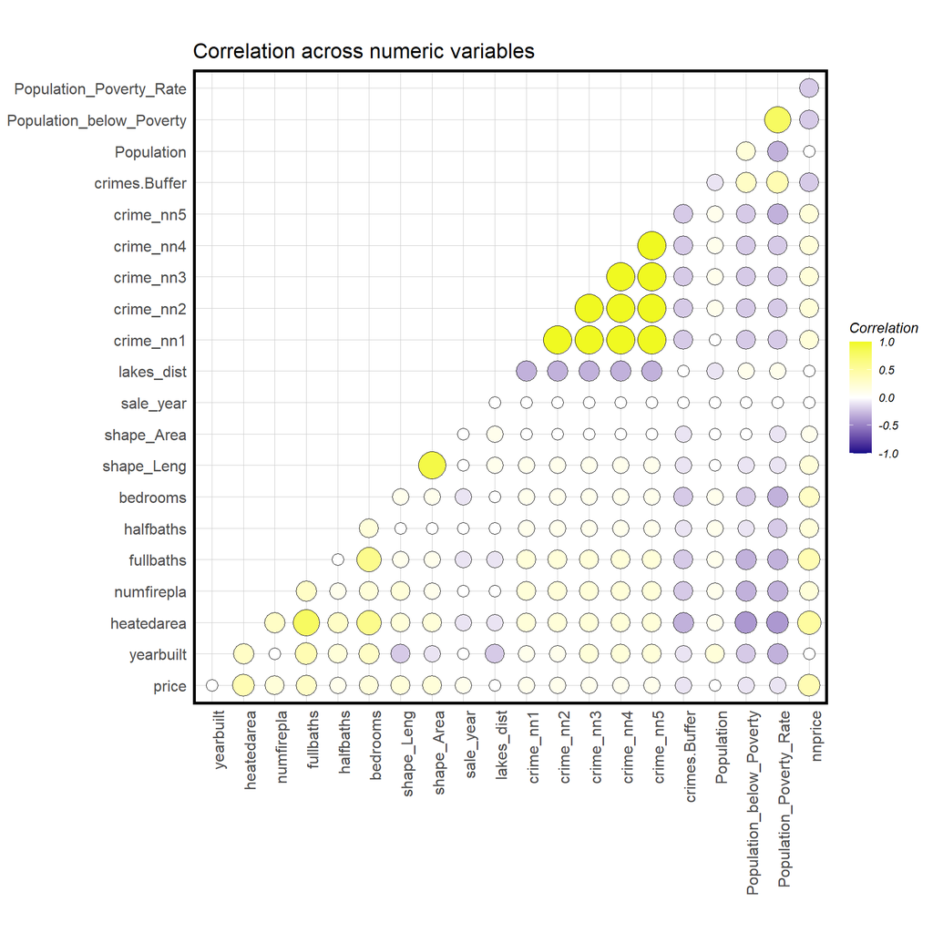

```r
ggcorrplot(
  round(cor(numericVars), 1),
  method = "circle",
  outline.color = "black",
  legend.title = "Correlation",
  p.mat = cor_pmat(numericVars),
  colors = c("#0d0887", "white", "#f0f921"),
  type="lower",
  insig = "blank") +
    labs(title = "Correlation across numeric variables")+
  # guides(fill=guide_legend(title="Correlation"))+
  plotTheme()+
  theme(axis.text.x = element_text(angle=90))
```

## 4.3 Home prices scatterplots

From these scatter plots, we see nearest neighbor price has a significantly positive correlation to price, crime nearest neighbor 5 has a somewhat positive correlation to price, distance to lakes has almost no correlation to price, and population poverty rate within the census tract the home belongs to has a somewhat negative correlation to price.

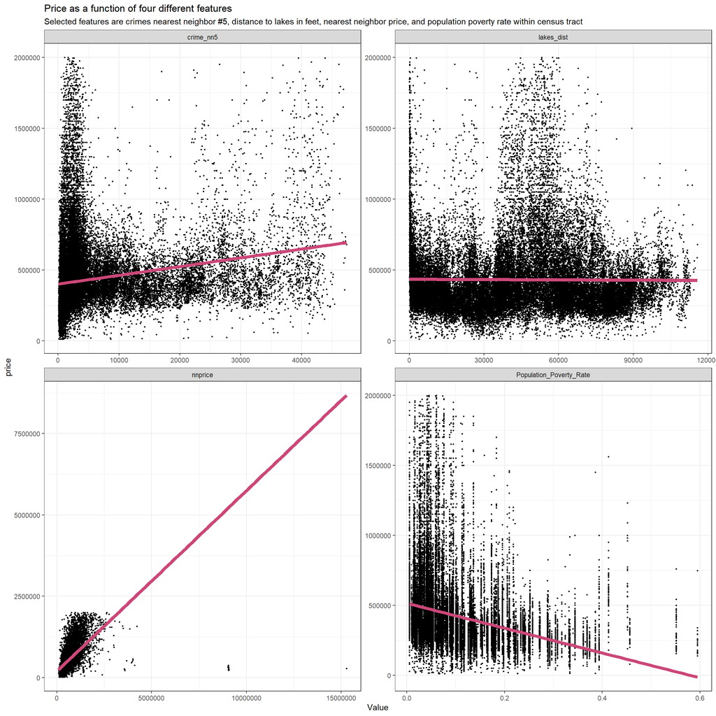

```r
st_drop_geometry(data.modelling) %>%
  dplyr::select(price, crime_nn5, lakes_dist, Population_Poverty_Rate, nnprice) %>%
  filter(price < 2000000 & price > 0) %>%
  gather(Variable, Value, -price) %>%
   ggplot(aes(Value, price)) +
     geom_point(size = .5, color="black")+ geom_smooth(method = lm, se=FALSE, colour = "#cc4778", size=2)+ scale_x_continuous(n.breaks=5)+
     facet_wrap(~Variable, ncol = 2, scales="free") +
     labs(title = "Price as a function of four different features", subtitle="Selected features are crimes nearest neighbor #5, distance to lakes in feet, nearest neighbor price, and population poverty rate within census tract")+
  theme_bw()
```

## 4.4 Map of Sale Price

From this map we can see clustering of higher price homes in the south-central and northern part of the county. Many of the lower valued homes seem to be in the downtown area. When branching out from the center, prices seem to rise in value. Overall, there is a pretty significant pattern of clustering with some randomness.

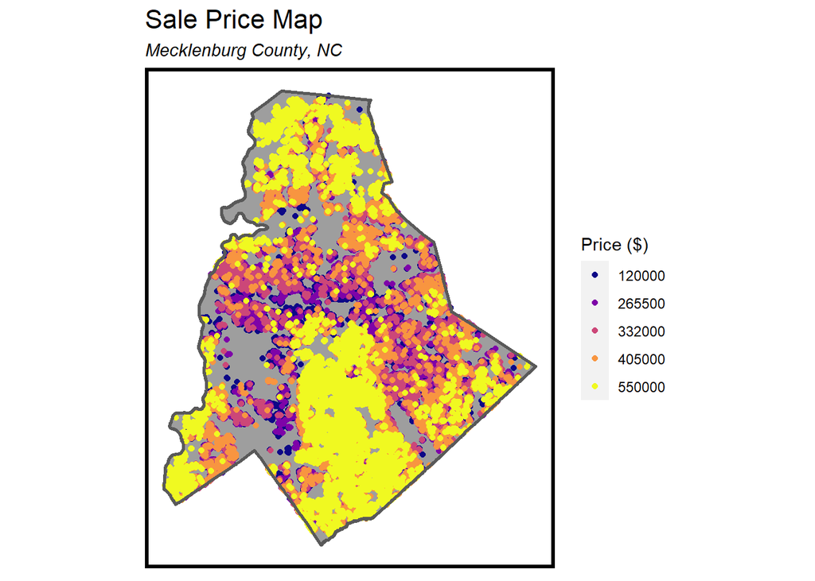

```r
ggplot()+
  geom_sf(data = mecklenburg, fill=40)+
  geom_sf(data = data.modelling, aes(color = q5(price)))+
  scale_color_manual(values = palette1, labels = (qBr(data.modelling, "price")), name="Price ($)", ) +
  labs(title="Sale Price Map", subtitle = "Mecklenburg County, NC")+
  geom_sf(data = mecklenburg, fill = "transparent", size=1) +
  mapTheme()
```

## 4.5 Map 1 - Crime Nearest Neighbor

This map also shows a clustering pattern for nearest neighbor crime events. Arguably, because there is greater population density in the downtown core, a household may be closer to crime. The map does show a similar pattern to the sale price map, indicating a potential relationship between price and proximity to crime.

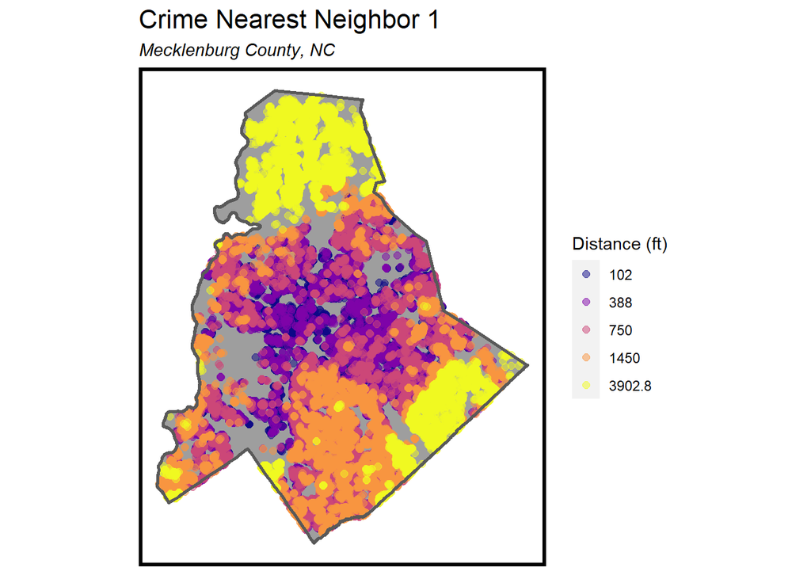

```r
ggplot()+
  geom_sf(data = mecklenburg, fill=40)+
  geom_sf(data = data.modelling, aes(color = q5(crime_nn1)), size=2, alpha=0.5)+
  labs(title="Crime Nearest Neighbor 1", subtitle="Mecklenburg County, NC")+
  scale_color_manual(values = palette1, labels = (qBr(data.modelling, "crime_nn1")), name="Distance (ft)") +
  mapTheme()+
  geom_sf(data = mecklenburg,
          fill = "transparent",
          size=1)
```

## 4.6 Map 2 - 100 Year Floodplain

This data show whether a house is located in a 100 year floodplain. On its own, the floodplain map is quite uninteresting because there is no surprise that proximity to a water body places a house at greater risk of a flood event. Thus, contextualizing with sale prices for houses in the floodplain helps visualize whether or not being in a floodplain reduces home price value. This map makes it seem like house price value is not impacted by floodplains, which could be true. Floodplains historically reduce property value, and flooding events have caused house prices to diminish from what they could have been sold for. This visualization may not answer the question of how individual houses in a floodplain are valued against other houses closer by in the floodplain.

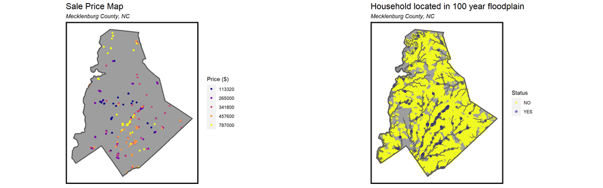

```r
data.modelling.Flood <- data.modelling %>%
  dplyr::select(price, in_floodplain) %>%
  filter(in_floodplain == "YES")

grid.arrange(ncol = 2,
ggplot()+
geom_sf(data = mecklenburg, fill=40)+
geom_sf(data = data.modelling.Flood, aes(color = q5(price)))+
scale_color_manual(values = palette1, labels = (qBr(data.modelling.Flood, "price")), name="Price ($)", ) +
labs(title="Sale Price Map", subtitle = "Mecklenburg County, NC")+
geom_sf(data = mecklenburg, fill = "transparent", size=1) +
mapTheme(),
ggplot()+
  geom_sf(data = mecklenburg, fill=40)+
  geom_sf(data = data.modelling, aes(color = in_floodplain), alpha=0.5, size=2)+
  scale_color_manual(values=c("#f0f921", "#0d0887"), name="Status")+
  labs(title= "Household located in 100 year floodplain", subtitle="Mecklenburg County, NC")+
  geom_sf(data = mecklenburg,
          fill = "transparent",
          size=1)+
  geom_sf(data = floodplain,
          fill = "transparent")+
  mapTheme())
```

## 4.7 Map 3 - School Catchment Zone Performance

The school catchment zone grades are determined by the state of North Carolina and were recently released for the 2021-2022 school year. These maps visualize the grade the school each household is zoned for received. We see increased clustering from elementary to middle to high, and there are some similar patterns among house price and grade received (eg. high valued homes in north and south-central part of the county are also where “A” and “B” schools are). Public school funding is notorious for inequitable distribution of resources, perpetuating wealth dispatity in the education system, so the similar pattern is to be expected.

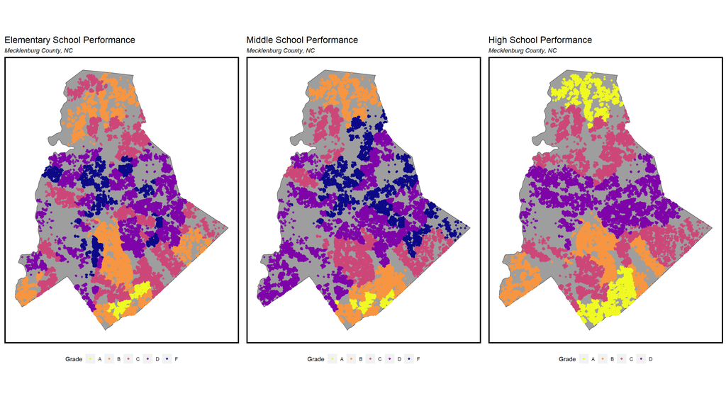

```r
grid.arrange(ncol = 3,
  ggplot() +
    geom_sf(data = mecklenburg, fill=40)+
    geom_sf(data = data.modelling, aes(color = ELEM_Performance), alpha=0.8)+
    scale_color_manual(values=c(palette2), name="Grade")+
    labs(title="Elementary School Performance", subtitle="Mecklenburg County, NC")+
    mapTheme()+theme(legend.position="bottom", legend.direction="horizontal"),
  ggplot() +
    geom_sf(data = mecklenburg, fill=40)+
    geom_sf(data = data.modelling, aes(color = MIDD_Performance), alpha=0.8)+
    scale_color_manual(values=c(palette2), name="Grade")+
    labs(title="Middle School Performance", subtitle= "Mecklenburg County, NC")+
    mapTheme()+theme(legend.position="bottom", legend.direction="horizontal"),
  ggplot() +
    geom_sf(data = mecklenburg, fill=40)+
    geom_sf(data = data.modelling, aes(color = HIGH_Performance), alpha=0.8)+
    scale_color_manual(values=c(palette2), name="Grade")+
    labs(title="High School Performance", subtitle="Mecklenburg County, NC")+
    mapTheme()+theme(legend.position="bottom", legend.direction="horizontal"))
```

## 4.8 Another interesting map - Waterfront Properties

Using a buffer method, we determined properties that were waterfront, specifically along one of three major lakes in Mecklenburg County. As we can see, having a waterfront property seems to increase property value, as most of the house values are in the upper threshold of the price scale.

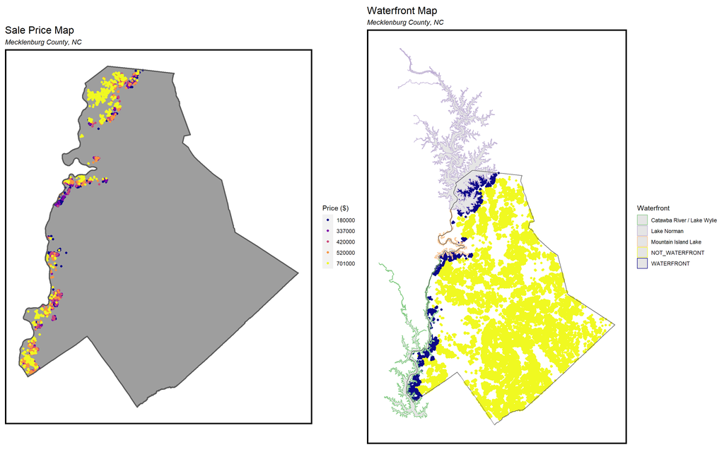

```r
data.modelling.WF <- data.modelling %>%
  dplyr::select(price, waterfront) %>%
  filter(waterfront == "WATERFRONT")

grid.arrange(ncol = 2,
ggplot()+
geom_sf(data = mecklenburg, fill=40)+
geom_sf(data = data.modelling.WF, aes(color = q5(price)))+
scale_color_manual(values = palette1, labels = (qBr(data.modelling.WF, "price")), name="Price ($)", ) +
labs(title="Sale Price Map", subtitle = "Mecklenburg County, NC")+
geom_sf(data = mecklenburg, fill = "transparent", size=1) +
mapTheme(),
ggplot()+
  geom_sf(data = lakes, fill=40)+

  geom_sf(data = data.modelling, aes(color = waterfront))+
  scale_color_manual(values =c("#7fc97f", "#beaed4", "#fdc086", "#f0f921", "#0d0887"), name="Waterfront")+
  labs(title="Waterfront Map", subtitle="Mecklenburg County, NC")+

  geom_sf(data = lakes, aes(color = feat_type))+

  geom_sf(data = mecklenburg,
          fill = "transparent")+
  mapTheme())
```

# 5 Results

## 5.1 Training

We split our modelling data into a test and training set. We then trained our model on the training data and tested it on the test data using Ordinary Least Squares regression.

```r
# data$municipali <- factor(data$municipali,
#                           levels = unique(data$municipali))

inTrain <- createDataPartition(
              y = paste(data.modelling$aheatingty, data.modelling$municipali, data.modelling$cdebuildin, data.modelling$descbuildi, data.modelling$storyheigh, data.modelling$heatedfuel, data.modelling$actype, data.modelling$extwall, data.modelling$foundation, data.modelling$bldggrade, data.modelling$old_mansion, data.modelling$house_vintage, data.modelling$house_age, data.modelling$waterfront, data.modelling$qmiwaterfront, data.modelling$lake_house, data.modelling$starter_house, data.modelling$street_dir, data.modelling$in_floodplain, data.modelling$in_histdist, data.modelling$historic_home, data.modelling$ELEM_NAME, data.modelling$ELEM_Performance, data.modelling$MIDD_NAME, data.modelling$MIDD_Performance, data.modelling$HIGH_NAME, data.modelling$HIGH_Performance), #data$price, #remove from test set those parameters whose categories only have one instance.
              p = 0.60, list = FALSE) # set up 60/40 training/testing set.

data.training <- data.modelling[inTrain,]
data.test <- data.modelling[-inTrain,]
```

```r
parameters.reg.training <- c("municipali", "dateofsale", "price", "yearbuilt", "heatedarea", "cdebuildin", "descbuildi", "storyheigh", "aheatingty", "heatedfuel", "actype", "extwall", "foundation", "numfirepla", "bldggrade", "fullbaths",  "halfbaths", "bedrooms", "units", "sale_year", "crime_nn1", "crime_nn2", "crime_nn3", "crime_nn4", "crime_nn5", "old_mansion", "house_vintage", "crimes.Buffer", "waterfront", "qmiwaterfront", "starter_house", "street_dir", "in_floodplain", "in_histdist", "historic_home", "lakes_dist", "nnprice", "ELEM_NAME", "ELEM_Performance", "MIDD_NAME", "MIDD_Performance", "HIGH_NAME", "HIGH_Performance", "npa", "Population_Poverty_Rate")

reg.training <- lm(price ~ ., data = st_drop_geometry(data.training) %>%
                            dplyr::select(all_of(parameters.reg.training)))

regression_summary <- tab_model(reg.training, show.reflvl = T, show.intercept = T, p.style = "numeric_stars")

regression_summary
```

price

Predictors

Estimates

CI

p

(Intercept)

-114075055.42 ***

-148018203.24 – -80131907.60

**<0.001**

actypeAC-CHLD WAT

-67305.73

-467037.70 – 332426.24

0.741

actypeAC-NONE

-29879.11

-64193.32 – 4435.09

0.088

actypeAC-PCKD ROOF

4436.41

-794146.61 – 803019.43

0.991

actypeAC-WALL UNIT

2281.52

-165085.15 – 169648.20

0.979

actypeAIR-DUCTED

-8483.78

-139990.93 – 123023.36

0.899

actypeAIR-NO-DUCT

-83379.30

-410404.07 – 243645.48

0.617

actypeHEAT - NONE

221055.76

-380286.20 – 822397.72

0.471

actypeHEAT PUMP

102253.77

-13910.58 – 218418.11

0.084

aheatingtyAC-WALL UNIT

79843.86

-393646.76 – 553334.47

0.741

aheatingtyAIR-DUCTED

9986.29

-88303.98 – 108276.56

0.842

aheatingtyAIR-NO-DUCT

2732.83

-113096.52 – 118562.19

0.963

aheatingtyBASEBOARD

23581.52

-91662.66 – 138825.70

0.688

aheatingtyHEAT - NONE

12015.59

-199272.66 – 223303.83

0.911

aheatingtyHEAT PUMP

10084.43

-90323.10 – 110491.96

0.844

aheatingtyHOT WATER

160085.24

-115888.73 – 436059.21

0.256

aheatingtyRADIANT CEIL

-224695.02

-1030370.32 – 580980.28

0.585

aheatingtyRADIANT WTR

-81404.38

-953955.39 – 791146.62

0.855

aheatingtySTEAM

-32000.53

-913938.58 – 849937.51

0.943

bedrooms

-12770.38 ***

-19366.29 – -6174.46

**<0.001**

bldggradeCUSTOM

1102072.55 ***

1030198.35 – 1173946.76

**<0.001**

bldggradeEXCELLENT

486935.93 ***

443997.99 – 529873.87

**<0.001**

bldggradeFAIR

-23318.89

-70285.67 – 23647.90

0.330

bldggradeGOOD

29902.04 ***

13938.35 – 45865.72

**<0.001**

bldggradeMINIMUM

-2751.34

-260464.85 – 254962.16

0.983

bldggradeVERY GOOD

153479.14 ***

127890.47 – 179067.82

**<0.001**

cdebuildin01T

-78559.33

-644754.42 – 487635.76

0.786

cdebuildin05

-75029.72

-273594.92 – 123535.49

0.459

cdebuildin08

-32979.68

-249278.85 – 183319.50

0.765

cdebuildin62

-452423.44 ***

-516774.91 – -388071.97

**<0.001**

cdebuildin69

-61840.65

-865210.85 – 741529.55

0.880

crime_nn1

0.81

-12.36 – 13.98

0.904

crime_nn2

1.08

-35.65 – 37.81

0.954

crime_nn3

-14.78

-66.01 – 36.45

0.572

crime_nn4

70.71 *

4.50 – 136.93

**0.036**

crime_nn5

-49.80 *

-87.93 – -11.67

**0.010**

crimes.Buffer

-760.61

-2357.53 – 836.30

0.351

dateofsale

122.62 ***

73.09 – 172.16

**<0.001**

ELEM_NAMEAllenbrook

37607.00

-92290.46 – 167504.47

0.570

ELEM_NAMEAshley Park

99345.51

-28399.34 – 227090.35

0.127

ELEM_NAMEBain

38536.76

-329857.46 – 406930.99

0.838

ELEM_NAMEBallantyne

-58782.52

-342498.82 – 224933.78

0.685

ELEM_NAMEBarnette

-123064.48

-266874.91 – 20745.94

0.093

ELEM_NAMEBerewick

-13232.99

-177669.49 – 151203.50

0.875

ELEM_NAMEBerryhill

25928.03

-109851.77 – 161707.83

0.708

ELEM_NAMEBeverly Woods

271971.10

-242446.94 – 786389.15

0.300

ELEM_NAMEBillingsville

-15523.19

-376926.33 – 345879.96

0.933

ELEM_NAMEBlythe

-46595.46

-166502.37 – 73311.46

0.446

ELEM_NAMEBriarwood

-57575.18

-307275.00 – 192124.63

0.651

ELEM_NAMEBruns Academy

102444.07

-6739.82 – 211627.97

0.066

ELEM_NAMEByers

87170.22

-86947.32 – 261287.75

0.326

ELEM_NAMECharles H Parker Academic Center

153979.62

-260289.90 – 568249.15

0.466

ELEM_NAMECharlotte East Language Academy

-78113.35

-443461.64 – 287234.94

0.675

ELEM_NAMEClear Creek

53430.60

-341076.60 – 447937.80

0.791

ELEM_NAMECornelius

-144502.75

-301879.37 – 12873.87

0.072

ELEM_NAMECotswold

30275.77

-310260.91 – 370812.45

0.862

ELEM_NAMECroft Community

-40503.27

-144696.65 – 63690.11

0.446

ELEM_NAMECrown Point

128882.11

-265709.81 – 523474.03

0.522

ELEM_NAMEDavid Cox

-29657.19

-131264.85 – 71950.46

0.567

ELEM_NAMEDavidson

-112729.80

-249205.49 – 23745.90

0.105

ELEM_NAMEDevonshire

68262.12

-131136.64 – 267660.89

0.502

ELEM_NAMEDilworth Latta Campus

161312.26

-250061.79 – 572686.31

0.442

ELEM_NAMEDilworth Sedgefield Campus

113959.52

-301870.48 – 529789.51

0.591

ELEM_NAMEDruid Hills

87997.17

-44505.15 – 220499.50

0.193

ELEM_NAMEEastover

231001.45

-180164.39 – 642167.29

0.271

ELEM_NAMEElizabeth

-13794.36

-335912.88 – 308324.17

0.933

ELEM_NAMEElon Park

-70268.20

-349885.91 – 209349.51

0.622

ELEM_NAMEEndhaven

13244.56

-217471.02 – 243960.14

0.910

ELEM_NAMEFirst Ward Creative Arts

62949.36

-405955.04 – 531853.76

0.792

ELEM_NAMEGovernors Village

-7925.10

-110563.07 – 94712.88

0.880

ELEM_NAMEGrand Oak

-123682.71

-275833.32 – 28467.91

0.111

ELEM_NAMEGreenway Park

-32814.21

-131149.09 – 65520.68

0.513

ELEM_NAMEHawk Ridge

-46833.33

-312016.79 – 218350.13

0.729

ELEM_NAMEHickory Grove

-1090.71

-194355.03 – 192173.62

0.991

ELEM_NAMEHidden Valley

-93513.06

-348673.35 – 161647.23

0.473

ELEM_NAMEHighland Creek

-50145.49

-146060.80 – 45769.82

0.305

ELEM_NAMEHighland Renaissance Academy

-18993.20

-278017.01 – 240030.62

0.886

ELEM_NAMEHornets Nest

-29920.25

-164484.28 – 104643.77

0.663

ELEM_NAMEHuntersville

-39076.14

-156689.28 – 78536.99

0.515

ELEM_NAMEHuntingtowne Farms

241334.51

-276310.60 – 758979.62

0.361

ELEM_NAMEIdlewild

-6358.18

-107727.55 – 95011.20

0.902

ELEM_NAMEJ.H. Gunn

-39028.28

-118535.20 – 40478.65

0.336

ELEM_NAMEJ.V. Washam

-95165.36

-236006.00 – 45675.28

0.185

ELEM_NAMEJ.W. Grier

-28692.15

-115192.31 – 57808.01

0.516

ELEM_NAMELake Wylie

-14155.60

-149568.36 – 121257.16

0.838

ELEM_NAMELawrence Orr

-2386.82

-170152.05 – 165378.42

0.978

ELEM_NAMELebanon Road

152491.66

-241493.52 – 546476.83

0.448

ELEM_NAMELong Creek

-3154.36

-143081.88 – 136773.16

0.965

ELEM_NAMEMallard Creek

-39396.40

-141192.98 – 62400.19

0.448

ELEM_NAMEMarie G. Davis

4175.88

-896527.70 – 904879.46

0.993

ELEM_NAMEMatthews

-22337.96

-323398.24 – 278722.32

0.884

ELEM_NAMEMcAlpine

-13045.07

-269787.03 – 243696.90

0.921

ELEM_NAMEMcKee Road

-74245.06

-342599.39 – 194109.27

0.588

ELEM_NAMEMerry Oaks

128633.34 *

8582.98 – 248683.71

**0.036**

ELEM_NAMEMint Hill

31459.17

-353650.67 – 416569.01

0.873

ELEM_NAMEMontclaire

37446.30

-309742.65 – 384635.26

0.833

ELEM_NAMEMountain Island

-11606.18

-137493.57 – 114281.20

0.857

ELEM_NAMENations Ford

50556.00

-100089.42 – 201201.42

0.511

ELEM_NAMENewell

-103671.40

-340961.00 – 133618.19

0.392

ELEM_NAMEOakdale

2071.05

-113548.58 – 117690.67

0.972

ELEM_NAMEOakhurst

126934.94 **

31589.45 – 222280.43

**0.009**

ELEM_NAMEOlde Providence

58775.22

-270389.78 – 387940.22

0.726

ELEM_NAMEPalisades Park

-40316.44

-167883.82 – 87250.94

0.536

ELEM_NAMEParkside

-45053.46

-152946.60 – 62839.67

0.413

ELEM_NAMEPaw Creek

8366.72

-114201.05 – 130934.49

0.894

ELEM_NAMEPineville

17630.47

-212773.18 – 248034.13

0.881

ELEM_NAMEPinewood

80714.60

-264227.96 – 425657.16

0.646

ELEM_NAMEPiney Grove

-6332.58

-168872.18 – 156207.02

0.939

ELEM_NAMEPolo Ridge

10752.53

-239549.11 – 261054.16

0.933

ELEM_NAMEProvidence Spring

-75357.24

-363120.17 – 212405.69

0.608

ELEM_NAMERama Road

34790.39

-53249.17 – 122829.96

0.439

ELEM_NAMERea Farms

-61726.41

-166425.26 – 42972.43

0.248

ELEM_NAMEReedy Creek

-61565.31

-144738.89 – 21608.28

0.147

ELEM_NAMEReid Park

83012.70

-530889.28 – 696914.68

0.791

ELEM_NAMERenaissance West

79101.51

-298038.20 – 456241.21

0.681

ELEM_NAMERiver Gate

-27057.47

-145690.60 – 91575.66

0.655

ELEM_NAMERiver Oaks Academy

-2454.65

-128900.58 – 123991.28

0.970

ELEM_NAMESelwyn

210674.55

-132741.70 – 554090.80

0.229

ELEM_NAMEShamrock Gardens

156181.18 **

63087.03 – 249275.34

**0.001**

ELEM_NAMESharon

155337.77

-180455.23 – 491130.77

0.365

ELEM_NAMESmithfield

32.17

-226137.48 – 226201.82

1.000

ELEM_NAMESouth Pine Academy

19989.69

-128844.05 – 168823.43

0.792

ELEM_NAMEStarmount Academy

260554.39

-258624.38 – 779733.17

0.325

ELEM_NAMEStatesville Road

3220.05

-107397.47 – 113837.56

0.955

ELEM_NAMESteele Creek

-1996.69

-165138.37 – 161144.99

0.981

ELEM_NAMESterling

30343.15

-253402.13 – 314088.43

0.834

ELEM_NAMEStoney Creek

-140263.72

-288575.40 – 8047.96

0.064

ELEM_NAMEThomasboro

44109.14

-80941.86 – 169160.13

0.489

ELEM_NAMETorrence Creek

-87005.13

-228248.63 – 54238.37

0.227

ELEM_NAMETuckaseegee

-1286.24

-121639.36 – 119066.89

0.983

ELEM_NAMEUniversity Meadows

-171162.99 *

-320892.52 – -21433.47

**0.025**

ELEM_NAMEUniversity Park

67751.08

-73900.26 – 209402.43

0.349

ELEM_NAMEVilla Heights

155168.93 **

52014.81 – 258323.05

**0.003**

ELEM_NAMEWesterly Hills

85354.43

-527606.13 – 698314.98

0.785

ELEM_NAMEWhitewater Academy

18677.11

-100670.04 – 138024.25

0.759

ELEM_NAMEWinding Springs

-76265.28

-218285.12 – 65754.57

0.293

ELEM_NAMEWindsor Park

58237.70

-40875.89 – 157351.30

0.249

ELEM_NAMEWinget Park

-7258.42

-136887.71 – 122370.87

0.913

ELEM_NAMEWinterfield

12325.70

-130512.38 – 155163.78

0.866

extwallASB SHNG/SDG

-58706.14

-189059.38 – 71647.10

0.377

extwallBOARD&BATTEN

88958.62

-51232.70 – 229149.95

0.214

extwallCEDAR,RDWD

37158.77

-8109.96 – 82427.51

0.108

extwallCEM BR/SPL B

-23785.63

-179068.71 – 131497.46

0.764

extwallCOMP OR WLBD

59658.95

-402301.60 – 521619.50

0.800

extwallCONC BLOCK

75475.80

-109778.58 – 260730.18

0.425

extwallCORR MTL LGT

-75278.49

-672066.60 – 521509.62

0.805

extwallEXT PLYWOOD

18496.25

-58700.23 – 95692.72

0.639

extwallFACE BRICK

-4695.57

-22045.30 – 12654.16

0.596

extwallHARDIPLK/DSGN VINYL

14357.81

-2641.64 – 31357.27

0.098

extwallIMITATION STONE

-20840.48

-592129.93 – 550448.97

0.943

extwallLOG

97580.20

-109876.89 – 305037.30

0.357

extwallMASONITE

10306.03

-8570.95 – 29183.01

0.285

extwallMODULAR MTL

-49941.69

-529748.45 – 429865.06

0.838

extwallPREFIN MTL

-34876.05

-497803.10 – 428051.00

0.883

extwallRNFR CONC

-143455.21

-943800.72 – 656890.29

0.725

extwallSDG MIN/NONE

-27032.78

-592275.74 – 538210.18

0.925

extwallSIDG NO SHTG

-67907.70

-354450.40 – 218635.00

0.642

extwallSTONE

545579.33 ***

376771.80 – 714386.86

**<0.001**

extwallSTUCCO HRDCT

72414.17 ***

31900.30 – 112928.04

**<0.001**

extwallSTUCCO SYNTH

38313.59

-47726.27 – 124353.46

0.383

extwallWOOD ON SHTG

612.55

-25474.48 – 26699.57

0.963

extwallWOOD SHINGLE

62334.57

-13286.76 – 137955.90

0.106

foundationCRAWL SPACE

37418.06 *

3234.85 – 71601.28

**0.032**

foundationPIER-NO FOUND WALL

178803.79

-200314.86 – 557922.45

0.355

foundationSLAB-ABV GRD

94893.76

-29619.69 – 219407.21

0.135

foundationSLAB-COM

170898.54

-188180.37 – 529977.45

0.351

foundationSLAB-RES

47200.72 **

12012.57 – 82388.86

**0.009**

fullbaths

25885.11 ***

14909.80 – 36860.42

**<0.001**

halfbaths

20135.87 ***

8211.26 – 32060.49

**0.001**

heatedarea

137.88 ***

127.98 – 147.78

**<0.001**

heatedfuelGAS

-13349.02

-32026.03 – 5327.99

0.161

heatedfuelNONE

-62472.01

-333540.26 – 208596.24

0.651

heatedfuelOIL/WD/COAL

-6367.54

-79503.13 – 66768.06

0.864

heatedfuelSOLAR/GEOTHRM

-41184.48

-378094.83 – 295725.87

0.811

HIGH_NAMEButler

-33132.60

-179606.37 – 113341.17

0.658

HIGH_NAMEHarding

-1372.20

-382646.48 – 379902.07

0.994

HIGH_NAMEHopewell

7094.45

-66074.50 – 80263.40

0.849

HIGH_NAMEIndependence

-41350.06

-103972.54 – 21272.41

0.196

HIGH_NAMEMyers Park

127634.07

-267115.47 – 522383.60

0.526

HIGH_NAMEProvidence

7380.30

-140153.77 – 154914.38

0.922

historic_homeNOT_HISTORIC_HOME

-94959.86

-199065.05 – 9145.33

0.074

house_vintageNEW

-8333.80

-27052.24 – 10384.64

0.383

house_vintageOLD

-407443.87

-1213315.48 – 398427.75

0.322

in_floodplainYES

26011.48

-24565.73 – 76588.70

0.313

in_histdistNOT_HISTORIC_DISTRICT

24390.19

-69440.84 – 118221.22

0.610

lakes_dist

0.89

-0.54 – 2.32

0.223

MIDD_NAMEAlexander

11324.83

-57445.71 – 80095.36

0.747

MIDD_NAMEAlexander Graham

-32334.24

-544445.27 – 479776.79

0.902

MIDD_NAMECarmel

-164229.09

-671352.56 – 342894.37

0.526

MIDD_NAMECochrane

-30871.17

-217569.43 – 155827.09

0.746

MIDD_NAMECommunity House

57845.85

-203777.74 – 319469.44

0.665

MIDD_NAMECrestdale

-10327.72

-271630.40 – 250974.96

0.938

MIDD_NAMEJ.W. Wilson

-4409.36

-468540.61 – 459721.89

0.985

MIDD_NAMEJay M. Robinson

-6734.00

-239252.99 – 225785.00

0.955

MIDD_NAMEKennedy

206.25

-108821.56 – 109234.05

0.997

MIDD_NAMEMartin

82507.10

-36660.84 – 201675.04

0.175

MIDD_NAMEMartin Luther King

77994.39

-152383.38 – 308372.15

0.507

MIDD_NAMEMint Hill

-139143.37

-500350.22 – 222063.48

0.450

MIDD_NAMENortheast

-95084.12

-482571.71 – 292403.47

0.631

MIDD_NAMEQuail Hollow

-699.87

-203823.75 – 202424.00

0.995

MIDD_NAMESouth Charlotte

-63865.46

-301955.44 – 174224.51

0.599

municipaliCORNELIUS

78003.15

-5887.41 – 161893.71

0.068

municipaliDAVIDSON

-57087.54

-138097.30 – 23922.22

0.167

municipaliHUNTERSVILLE

-35418.76

-84666.64 – 13829.12

0.159

municipaliMATTHEWS

1135.71

-47514.13 – 49785.56

0.964

municipaliMINT HILL

2498.74

-59477.35 – 64474.84

0.937

municipaliPINEVILLE

-38856.60

-117758.14 – 40044.94

0.334

municipaliSTALLINGS

82812.62

-138817.82 – 304443.06

0.464

municipaliUNINC

-14137.38

-38053.35 – 9778.60

0.247

nnprice

0.18 ***

0.16 – 0.20

**<0.001**

npa

13.00

-39.93 – 65.94

0.630

numfirepla

-6908.56

-18980.37 – 5163.26

0.262

old_mansionOLD_MANSION

188090.29

-613070.96 – 989251.54

0.645

Population_Poverty_Rate

-63596.35

-182153.59 – 54960.89

0.293

qmiwaterfrontWATERFRONT

76331.54 ***

38875.91 – 113787.18

**<0.001**

sale_year

54258.34 ***

37044.25 – 71472.42

**<0.001**

starter_houseSTARTER_HOUSE

6249.92

-29815.12 – 42314.97

0.734

storyheigh1 STORY

140382.95

-322535.30 – 603301.20

0.552

storyheigh1.5 STORY

127793.23

-335215.96 – 590802.42

0.589

storyheigh2.0 STORY

92846.76

-369928.39 – 555621.91

0.694

storyheigh2.5 STORY

65720.15

-397664.96 – 529105.27

0.781

storyheigh3.0 STORY

14014.03

-461264.40 – 489292.46

0.954

storyheighBI-LEVEL

74169.80

-393333.14 – 541672.75

0.756

storyheighCAPE COD

125499.54

-375041.79 – 626040.88

0.623

storyheighRANCH W/BSMT

100561.41

-364253.96 – 565376.78

0.672

storyheighSPLIT LEVEL

105005.39

-358876.08 – 568886.87

0.657

street_dirN

3936.66

-132759.70 – 140633.01

0.955

street_dirNONE

34739.37

-58194.40 – 127673.15

0.464

street_dirS

-15033.39

-161586.19 – 131519.40

0.841

street_dirW

-5740.21

-141991.88 – 130511.45

0.934

units

364108.01 ***

360167.85 – 368048.17

**<0.001**

waterfrontWATERFRONT

-11104.17

-46117.68 – 23909.35

0.534

yearbuilt

800.32 **

212.48 – 1388.15

**0.008**

Observations

30082

R<sup>2</sup> / R<sup>2</sup> adjusted

0.642 / 0.639

- p<0.05 ** p<0.01 *** p<0.001

### 5.1.1 MAE and MAPE Table

This table provides a summary of mean absolute error (MAE) and mean absolute percent error (MAPE) for a single test set.

```r
#I'm not sure what they're referring to as a single test set for MAE and MAPE, but I'll run a regression to predict on the test set, and give the MAE and MAPE for that.

# Using last round's regression to predict prices for test set.

data.test <-
  data.test %>%
  mutate(Price.Predict = predict(reg.training, newdata = data.test), #newdata = data.test)
         Price.Error = Price.Predict - price,
         Price.AbsError = abs(Price.Predict - price),
         Price.APE = (abs(Price.Predict - price)) / Price.Predict)

# Take MAE and MAPE of the predictions test results
test_MAE <- mean(data.test$Price.AbsError, na.rm = T)

test_MAPE <- mean(data.test$Price.APE, na.rm = T)

# combine into a new df
MAE_MAPE_table <- data.frame(
  MAE = test_MAE,
  MAPE = test_MAPE)

# create a summary table of the df
MAE_MAPE_table %>%
  gather(Measurement, Value) %>%
  mutate(Value = round(Value, 3)) %>%
  kbl(title = "Mean Average Error and Mean Average Percent Error") %>%
  kable_classic_2(full_width = F)
```

| Measurement | Value |
| --- | --- |
| MAE | 81911.211 |
| MAPE | 0.337 |

### 5.1.2 K-Fold Cross-Validation

```r
# set up k-fold cross-validation with k = 100 folks
fitControl <- trainControl(method = "cv", number = 100)
set.seed(825) # reproducible folds

knn_cv <-
  train(price ~ ., data = st_drop_geometry(data.modelling) %>%
                                dplyr::select(all_of(parameters.reg.training)),
     method = "lm", trControl = fitControl, na.action = na.pass)
```

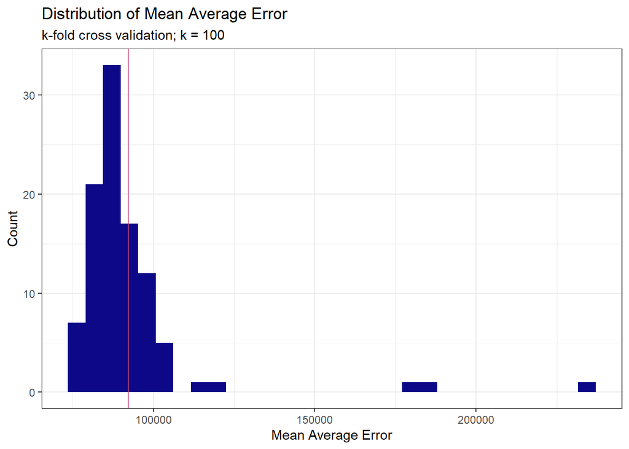

```r
kfoldcv_mae <- data.frame(knn_cv[["resample"]][["MAE"]]) %>%
  rename(MAE = "knn_cv...resample......MAE...")

ggplot()+
  geom_histogram(data = kfoldcv_mae, aes(x = MAE), fill = "#0d0887")+
  geom_vline(xintercept = (mean(kfoldcv_mae$MAE)), color = "#cc4778")+
  labs(title = "Distribution of Mean Average Error",
       subtitle = "k-fold cross validation; k = 100",
       x = "Mean Average Error",
       y = "Count")+
  theme_bw()
```

### 5.1.3 Predicted and observed prices

This plot demonstrates the difference between our model’s predicted sales price and the actual observed sales price. The gray line represents the perfect prediction; and the blue line represents our average prediction.

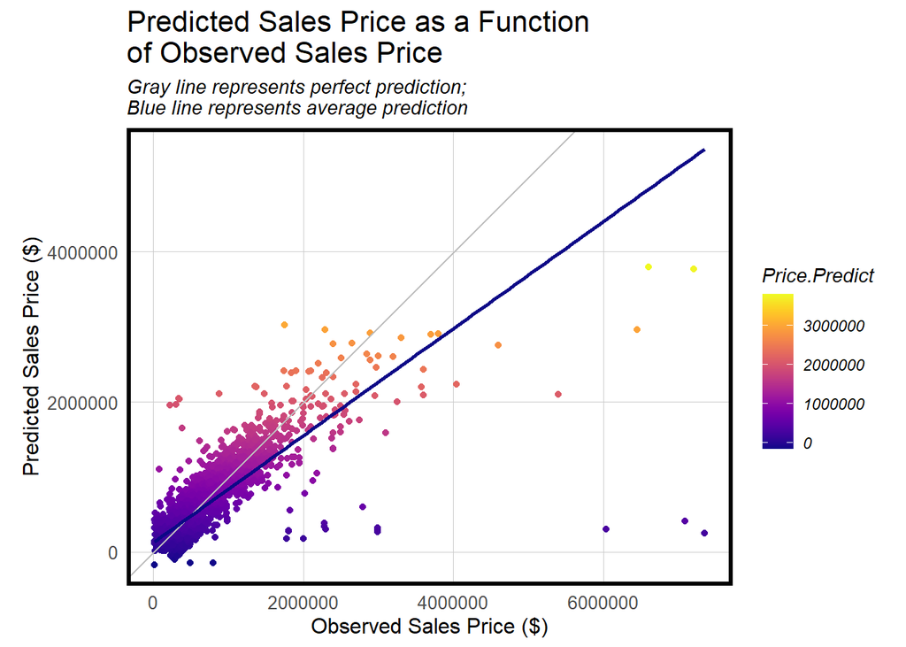

```r
# Using data.test from the MAE and MAPE section, here's a plot:

ggplot(data = data.test, aes(x=price, y=Price.Predict))+
  geom_point(aes(color = Price.Predict)) +
  scale_color_viridis(option = "plasma")+
  #geom_point(aes(color = price)) +
  coord_equal()+
  geom_abline(color = "gray") +
  geom_smooth(method = "lm", se = FALSE, color = "#0d0887") +
  labs(title = "Predicted Sales Price as a Function\nof Observed Sales Price",
       subtitle = "Gray line represents perfect prediction;\nBlue line represents average prediction",
       x = "Observed Sales Price ($)",
       y = "Predicted Sales Price ($)")+
  plotTheme()
```

## 5.2 Investigating Spatial Autocorrelation in Erros

### 5.2.1 Map of Residuals

Our model’s errors are mapped across Mecklenburg County below. While our errors are spread across the county, our largest errors are clustered to the north of the county, and in the center-south. This suggests that there are spatial characteristics that should be included in future models.

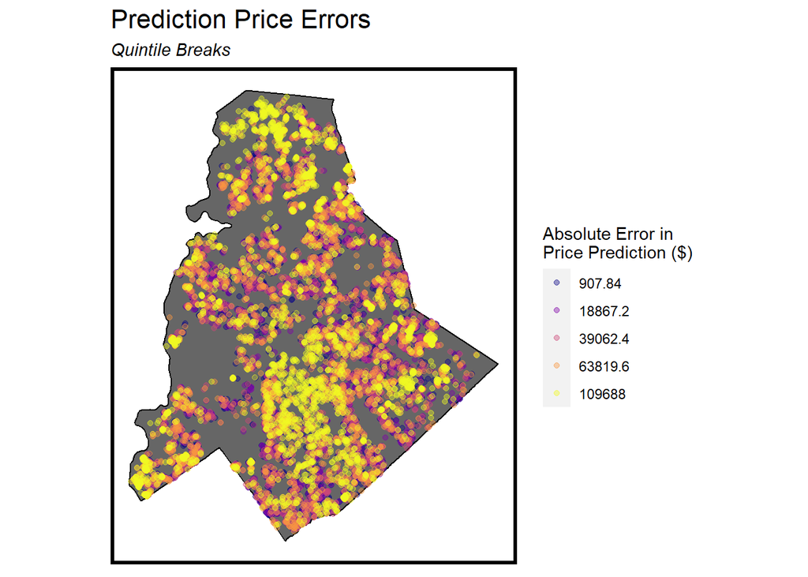

```r
ggplot()+
  geom_sf(data = mecklenburg, fill = "gray40", color = "black")+
  geom_sf(data = data.test, aes(color = q5(Price.AbsError)), alpha = 0.4)+
  scale_color_manual(values = palette1, labels = (qBr(data.test, "Price.AbsError"))) +
  labs(title = "Prediction Price Errors",
       subtitle = "Quintile Breaks",
       color = "Absolute Error in\nPrice Prediction ($)")+
  mapTheme()
```

```r
# Spatial Lag - calculates the average sale price of k nearest neighbors

coords <-  st_coordinates(data.modelling)

neighborList <- knn2nb(knearneigh(coords, 5))

spatialWeights <- nb2listw(neighborList, style="W")

data.modelling$lagPrice <- lag.listw(spatialWeights, data.modelling$price)
```

This chart plots observed sales prices as a function of the spatial lag of price. The spatial lag of price refers to the average price of the surrounding houses. The positive slope of the plot indicates that as neighboring houses’ price goes up, the observed sales price also rises. Said differently, houses tend to sell at prices similar to other houses near them.

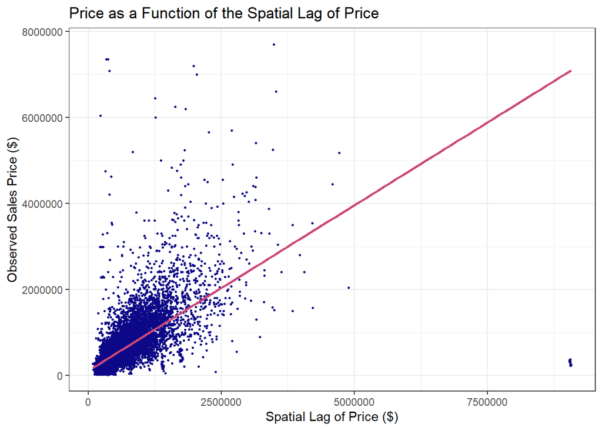

```r
st_drop_geometry(data.modelling) %>%
  dplyr::select(price, lagPrice) %>%
  filter(price < 10000000) %>%
  filter(lagPrice < 10000000) %>%
  gather(Variable, Value, -price) %>%
   ggplot(aes(Value, price)) +
     geom_point(size = .5, color = "#0d0887") + geom_smooth(method = "lm", se=F, colour = "#cc4778") +
     #facet_wrap(~Variable, ncol = 3, scales = "free") +
     labs(title = "Price as a Function of the Spatial Lag of Price",
          y = "Observed Sales Price ($)",
          x = "Spatial Lag of Price ($)") +
     plotTheme()+
  theme_bw()
```

### 5.2.2 Plot of spatial lag in errors

```r
# Spatial lag for errors

coords.test <-  st_coordinates(data.test)

neighborList.test <- knn2nb(knearneigh(coords.test, 5))

spatialWeights.test <- nb2listw(neighborList.test, style="W")


data.test <- data.test %>%
  mutate(lagPriceError = lag.listw(spatialWeights.test, Price.Error)) #, zero.policy = TRUE, NAOK=TRUE
```

The relationship between errors in observed sales prices and the errors in sales prices of homes’ five nearest neighbors is illustrated below. This plot demonstrates that as home price errors increase, sales price errors also increase. This indicates that errors in the model are spatially autocorrelated, and future models must take into account further aspects of the spatial process in Mecklenburg County.

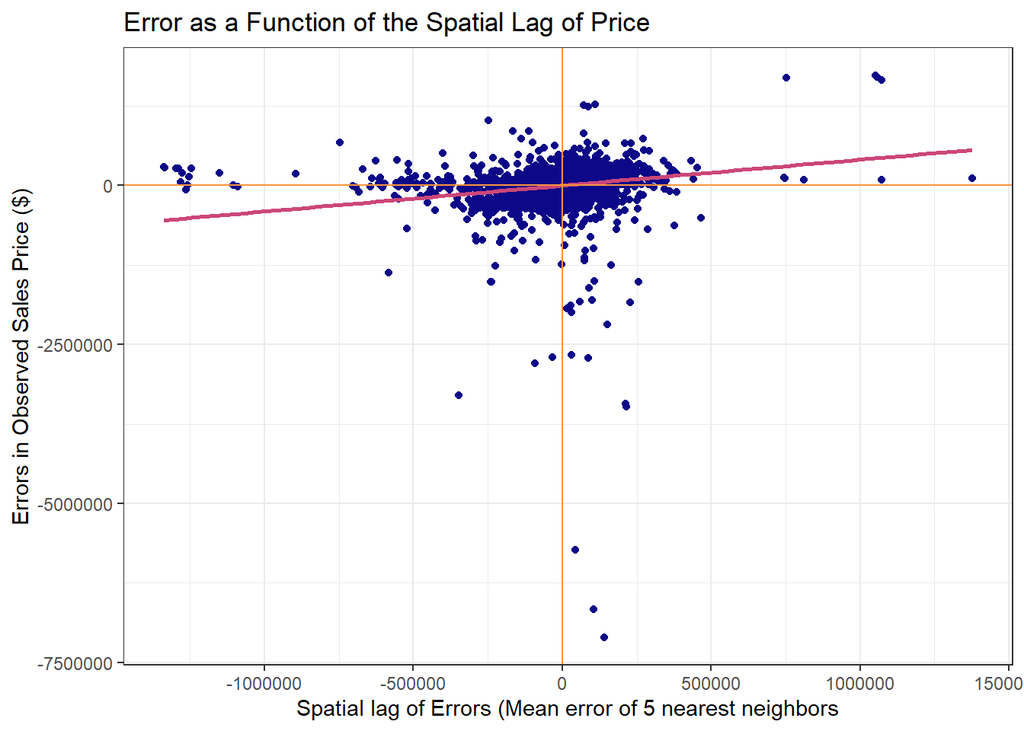

```r
ggplot(data = data.test, aes(lagPriceError, Price.Error))+
  geom_point(color = "#0d0887")+
  geom_smooth(method = "lm", se=F, color = "#cc4778") +
  geom_hline(yintercept=0, color="#f89540")+
  geom_vline(xintercept=0, color="#f89540")+
  labs(title = "Error as a Function of the Spatial Lag of Price",
        y = "Errors in Observed Sales Price ($)",
        x = "Spatial lag of Errors (Mean error of 5 nearest neighbors")+
  plotTheme()+
  theme_bw()
```

### 5.2.3 Moran’s I

```r
# Moran's I section:

moranTest <- moran.mc(data.test$Price.Error,
                      spatialWeights.test, nsim = 999)
```

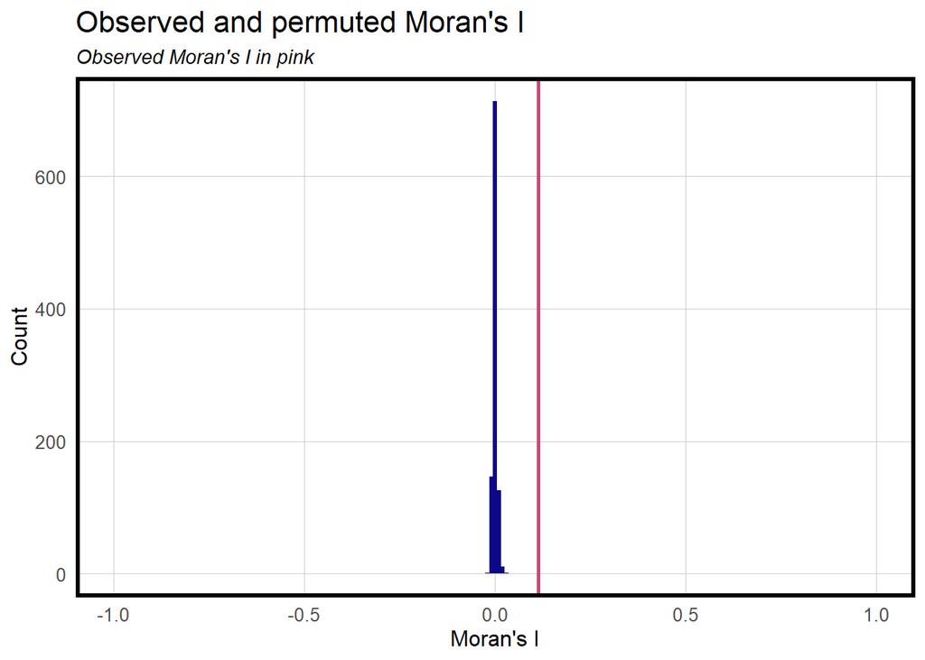

```r
ggplot(as.data.frame(moranTest$res[c(1:999)]), aes(moranTest$res[c(1:999)])) +
  geom_histogram(binwidth = 0.01, fill = "#0d0887") +
  geom_vline(aes(xintercept = moranTest$statistic), colour = "#cc4778",size=1) +
  scale_x_continuous(limits = c(-1, 1)) +
  labs(title="Observed and permuted Moran's I",
       subtitle= "Observed Moran's I in pink",
       x="Moran's I",
       y="Count") +
  plotTheme()
```

### 5.2.4 Map of predicted values

Below is a map of predicted house prices across Mecklenburg county, using our model to predict all homes’ prices.

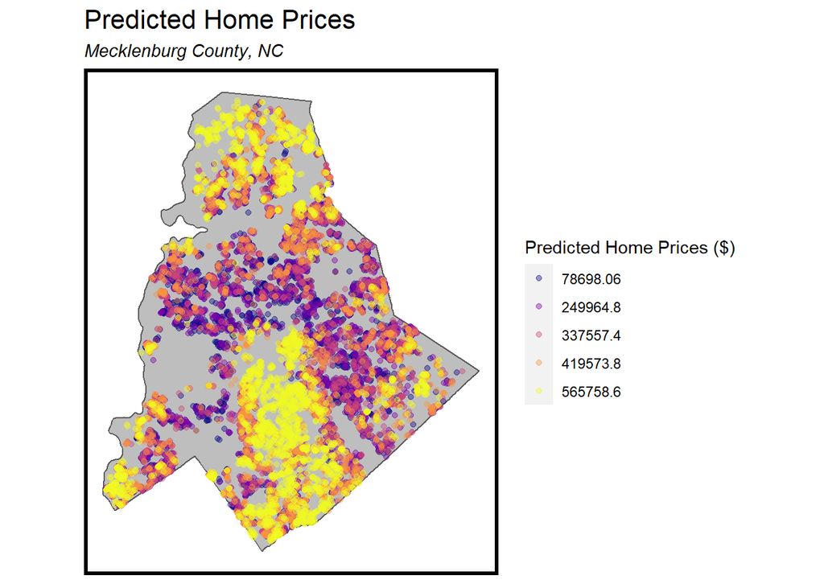

```r
ggplot()+
  geom_sf(data = mecklenburg, fill = "gray")+
  geom_sf(data = mass_prediction, aes(color = q5(Price.Predict)), alpha = 0.4)+
  scale_color_manual(values = palette1, labels = (qBr(data.test, "Price.Predict"))) +
  labs(title = "Predicted Home Prices",
       subtitle = "Mecklenburg County, NC",
       color = "Predicted Home Prices ($)")+
  mapTheme()
```

### 5.2.5 Map of MAPE by neighborhood

This map of MAPE by neighborhood shows areas where our model prediction errors are highest (yellow) and lowest (blue). In contrast to our previous map of price errors, our largest MAPEs are concentrated in neighborhoods that surround the east, west, and north of the city center.

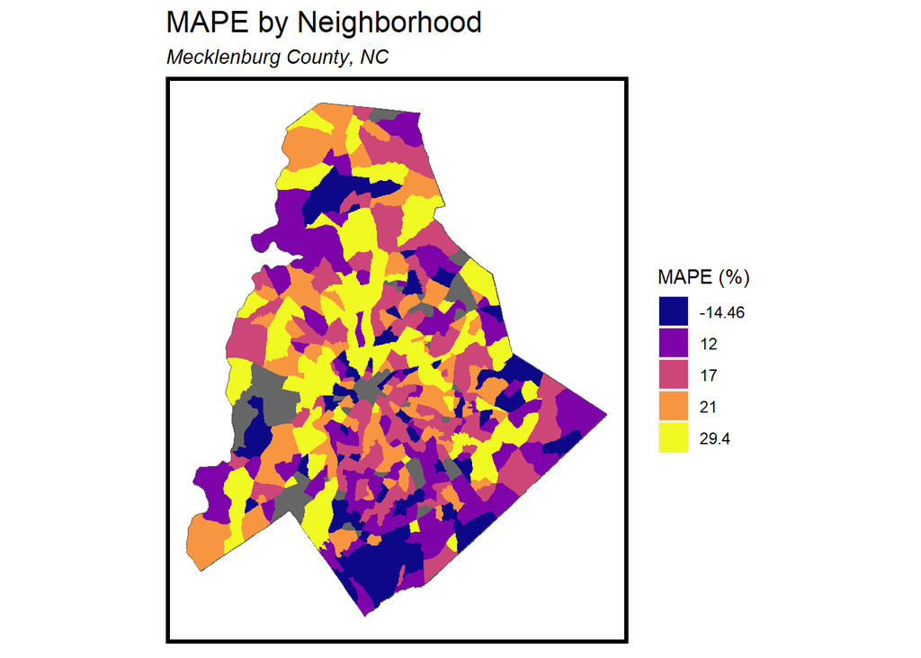

```r
# summarize MAPE by neighborhood
npa_means <- st_drop_geometry(data.test) %>%
    group_by(npa) %>%
    summarize(meanPrice = mean(price, na.rm = T),
              MAPE = mean(Price.APE, na.rm = T))

# join with hoods
npa_map <- merge(hoods, npa_means, by = "npa") %>%
  mutate(MAPE100 = MAPE*100)

# plot
ggplot()+
  geom_sf(data = mecklenburg, fill = "gray40")+
  geom_sf(data = npa_map, aes(fill = q5(MAPE100)), color = "transparent")+
  scale_fill_manual(values = palette1, labels = qBr(npa_map, "MAPE100"))+
  labs(title = "MAPE by Neighborhood",
       subtitle = "Mecklenburg County, NC",
       fill = "MAPE (%)")+
  mapTheme()
```

### 5.2.6 Scatterplot of MAPE

Below is a scatterplot plot of MAPE by neighborhood as a function of mean price by neighborhood. As home prices by neighborhood grow, the average percent error decreases, suggesting that our model may predict more inaccurately in neighborhoods with lower mean house values.

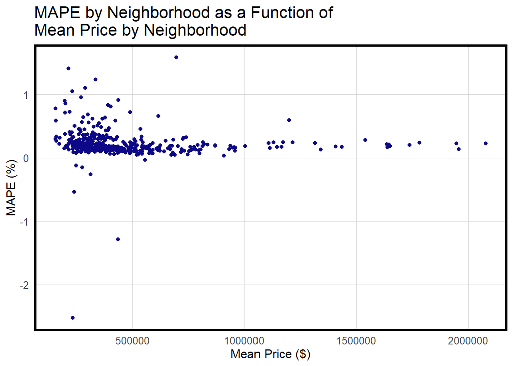

```r
npa_means %>%
  dplyr::filter(npa_means$MAPE < 2) %>%
ggplot(aes(x = meanPrice, y = MAPE))+
  geom_point(color = "#0d0887")+
  geom_abline(color = "#cc4778")+
  labs(title = "MAPE by Neighborhood as a Function of\nMean Price by Neighborhood",
       x = "Mean Price ($)",
       y = "MAPE (%)")+
  theme_bw()+
  plotTheme()
```

### 5.2.7 Generalizability of the Model

MAPE by Neighborhood Income Level (Low income area is defined as census tracts with more than 30% of residents living under the poverty line.)

```r
income_compare <- data.test %>%
  mutate(Tract_Income_Level = ifelse(Population_Poverty_Rate > 0.3, "Low Income", "Not Low Income")) %>%
  dplyr::select(npa, Tract_Income_Level, Price.AbsError, Price.APE) %>%
  group_by(Tract_Income_Level) %>%
  summarize(mean.MAPE = scales::percent(mean(Price.APE, na.rm = T))) %>%
  st_drop_geometry() %>%
  spread(Tract_Income_Level, mean.MAPE) %>%
  kbl(title = "MAPE by Neighborhood Income Level") %>%
  kable_classic_2(full_width = F)# %>%
  #footnote(general_title = "\n",
           #general = "Low income area is defined as census tracts with more than 30% of residents living under the poverty line.")

income_compare
```

| Low Income | Not Low Income |
| --- | --- |
| 23% | 34% |

# 6 Discussion

Our errors did appear to be spatially autocorrelated, with a positive Moran’s I and evidenced by the map showing the largest errors cluster in the county’s north, and central-south. This suggests that there is a spatial characteristic at play in Mecklenburg that our model did not take into account.

# 7 Conclusion and Recommendations